# Supervised Learning and Visualisation

Practical 4

Willem van Veluw

19-9-2022

For this practical we first load the necessary packages.

```r
library(tidyverse)
library(magrittr)
library(ISLR)
library(MASS)
```

### Exercise 1

```r
lm_ses <- lm(medv ~ lstat, Boston)
```

### Exercise 2

The variable `lstat` is expressed in percentages. Hence, we see that someone with a status of 0% has a housing value of 34.55. For every additional percentage, the housing value with decrease with 0.95.

```r
coef(lm_ses)
```

```
## (Intercept)       lstat
##  34.5538409  -0.9500494
```

### Exercise 3

Running the `summary()` function gives an overview of the results of the regression. One can read the estimated coefficients, its standard error, test statistic and p-value. In addition, `summary()` gives information about the fit of the regression by means of stating the residuals and some important measures of quality (residual standard error, R-squared and F-statistic).

```r
summary(lm_ses)
```

```
##
## Call:
## lm(formula = medv ~ lstat, data = Boston)
##
## Residuals:
##     Min      1Q  Median      3Q     Max
## -15.168  -3.990  -1.318   2.034  24.500
##
## Coefficients:
##             Estimate Std. Error t value Pr(>|t|)
## (Intercept) 34.55384    0.56263   61.41   <2e-16 ***
## lstat       -0.95005    0.03873  -24.53   <2e-16 ***
## ---
## Signif. codes:  0 '***' 0.001 '**' 0.01 '*' 0.05 '.' 0.1 ' ' 1
##
## Residual standard error: 6.216 on 504 degrees of freedom
## Multiple R-squared:  0.5441, Adjusted R-squared:  0.5432
## F-statistic: 601.6 on 1 and 504 DF,  p-value: < 2.2e-16
```

### Exercise 4

```r
y_pred <- predict(lm_ses)
```

### Exercise 5

If the fit was perfect, all points would be on a straight line. Then the predictions are equal to the observations. This is not the case in the fit of `lm_ses`. We see that, especially for high observed values, the prediction is off.

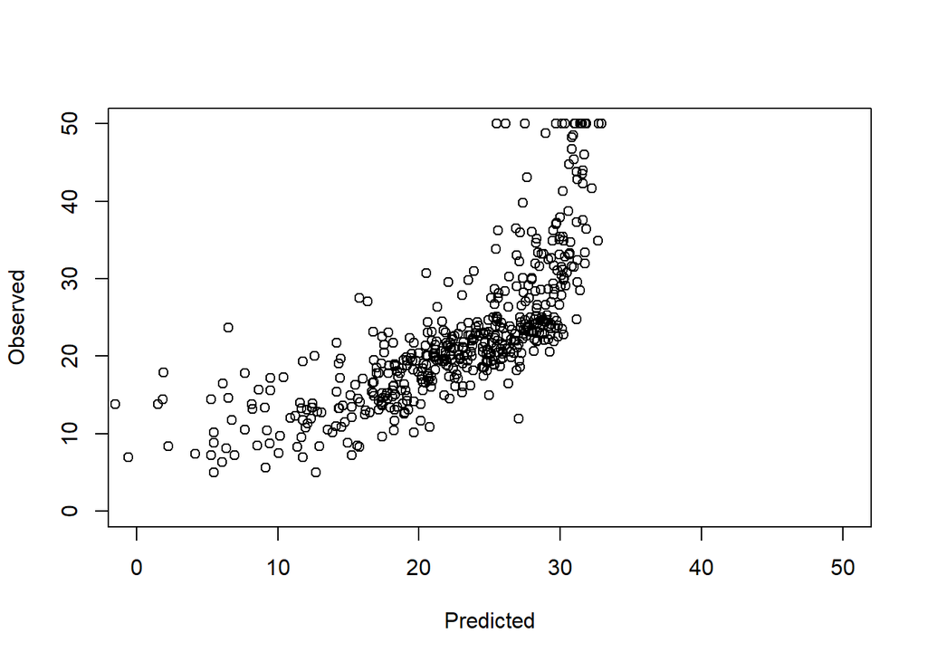

```r
plot(y_pred, Boston$medv,
     xlim = c(0,50),
     ylim = c(0,50),
     xlab = "Predicted",
     ylab = "Observed")
```

### Exercise 6

```r
pred_dat <- data.frame(lstat = seq(0,40, length.out = 1000))
```

### Exercise 7

```r
y_pred_new <- predict(lm_ses, newdata = pred_dat)
```

### Exercise 8

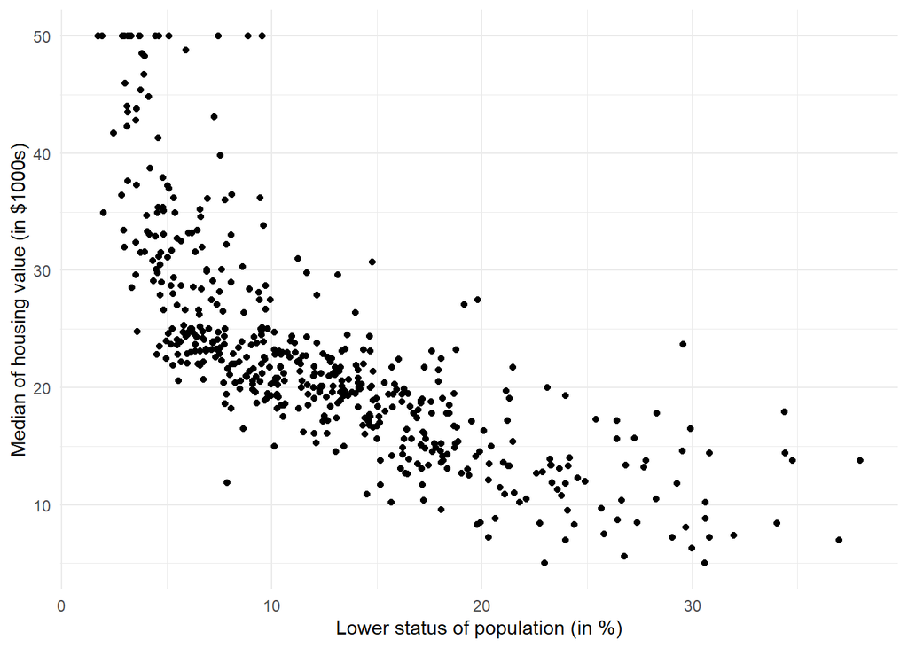

```r
p_scatter <- Boston %>%
  ggplot(aes(x = lstat, y = medv)) +
  geom_point() +
  labs(x = "Lower status of population (in %)", y = "Median of housing value (in $1000s)") +
  theme_minimal()

p_scatter
```

### Exercise 9

```r
pred_dat$medv = y_pred_new
```

### Exercise 10

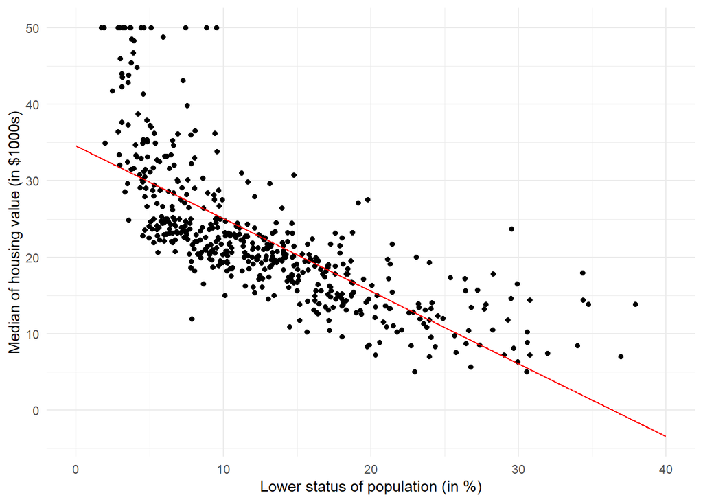

```r
p_scatter + geom_line(data = pred_dat, colour = "red")
```

### Exercise 11

In this object we have the prediction computed by the regression model and the lower- and upperbound of the 95% confidence interval.

```r
y_pred_95 <- predict(lm_ses, newdata = pred_dat, interval = "confidence")
head(y_pred_95)
```

```
##        fit      lwr      upr
## 1 34.55384 33.44846 35.65922
## 2 34.51580 33.41307 35.61853
## 3 34.47776 33.37768 35.57784
## 4 34.43972 33.34229 35.53715
## 5 34.40168 33.30690 35.49646
## 6 34.36364 33.27150 35.45578
```

### Exercise 12

```r
data_95 <- data.frame(lstat = pred_dat$lstat,
                      medv = y_pred_95[,1],
                      lower = y_pred_95[,2],
                      upper = y_pred_95[,3])
head(data_95)
```

|  | lstat | medv | lower | upper |
| --- | --- | --- | --- | --- |
| 1 | 0.00000000 | 34.55384 | 33.44846 | 35.65922 |
| 2 | 0.04004004 | 34.51580 | 33.41307 | 35.61853 |
| 3 | 0.08008008 | 34.47776 | 33.37768 | 35.57784 |
| 4 | 0.12012012 | 34.43972 | 33.34229 | 35.53715 |
| 5 | 0.16016016 | 34.40168 | 33.30690 | 35.49646 |
| 6 | 0.20020020 | 34.36364 | 33.27150 | 35.45578 |

### Exercise 13

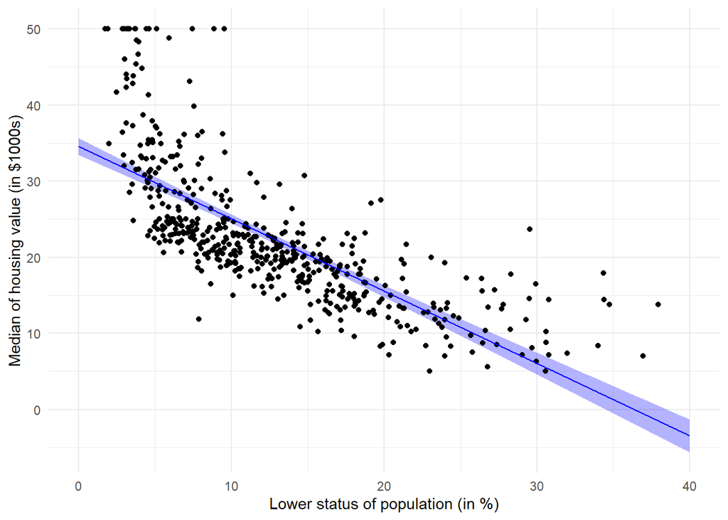

```r
Boston %>%
  ggplot(aes(x = lstat, y = medv)) +
  geom_ribbon(aes(ymin = lower, ymax = upper), data = data_95, fill = "blue", alpha = 0.3) +
  geom_point() +
  geom_line(data = pred_dat, colour = "blue") +
  labs(x = "Lower status of population (in %)", y = "Median of housing value (in $1000s)") +
  theme_minimal()
```

### Exercise 14

The ribbon represents the uncertainty of the regression predictions. For example, we are more certain when predicting the housing value for $lstat = 20$ then for $lstat = 40$. One can see that by the width of the ribbon at the respective values for `lstat`.

### Exercise 15

```r
y_pred_pred <- predict(lm_ses, newdata = pred_dat, interval = "prediction")
head(y_pred_pred)
```

```
##        fit      lwr      upr
## 1 34.55384 22.29192 46.81576
## 2 34.51580 22.25412 46.77748
## 3 34.47776 22.21632 46.73920
## 4 34.43972 22.17852 46.70092
## 5 34.40168 22.14071 46.66265
## 6 34.36364 22.10291 46.62437
```

```r
data_pred <- data.frame(lstat = pred_dat$lstat,
                      medv = y_pred_pred[,1],
                      lower = y_pred_pred[,2],
                      upper = y_pred_pred[,3])
head(data_pred)
```

|  | lstat | medv | lower | upper |
| --- | --- | --- | --- | --- |
| 1 | 0.00000000 | 34.55384 | 22.29192 | 46.81576 |
| 2 | 0.04004004 | 34.51580 | 22.25412 | 46.77748 |
| 3 | 0.08008008 | 34.47776 | 22.21632 | 46.73920 |
| 4 | 0.12012012 | 34.43972 | 22.17852 | 46.70092 |
| 5 | 0.16016016 | 34.40168 | 22.14071 | 46.66265 |
| 6 | 0.20020020 | 34.36364 | 22.10291 | 46.62437 |

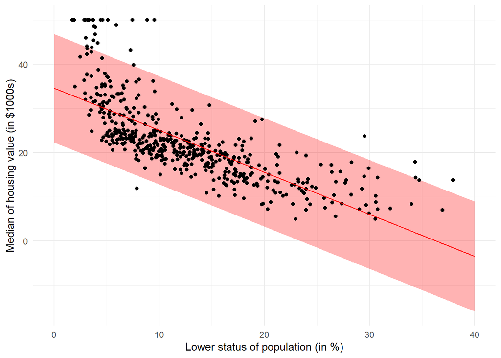

```r
Boston %>%
  ggplot(aes(x = lstat, y = medv)) +
  geom_ribbon(aes(ymin = lower, ymax = upper), data = data_pred, fill = "red", alpha = 0.3) +
  geom_point() +
  geom_line(data = pred_dat, colour = "red") +
  labs(x = "Lower status of population (in %)", y = "Median of housing value (in $1000s)") +
  theme_minimal()
```

### Exercise 16

```r
mse <- function(y_true, y_pred){
  return( mean((y_true-y_pred)^2) )
}
```

### Exercise 17

```r
mse(1:10, 10:1)
```

```
## [1] 33
```

### Exercise 18

```r
mse(Boston$medv, predict(lm_ses))
```

```
## [1] 38.48297
```

### Exercise 19

```r
splits <- c(rep("train", 253),
            rep("validation", 152),
            rep("test", 101)
)
```

### Exercise 20

```r
boston_master <- Boston %>% mutate(Set = sample(splits))
head(boston_master)
```

|  | crim | zn | indus | chas | nox | rm | age | dis | rad | tax | ptratio | black | lstat | medv | Set |
| --- | --- | --- | --- | --- | --- | --- | --- | --- | --- | --- | --- | --- | --- | --- | --- |
| 1 | 0.00632 | 18 | 2.31 | 0 | 0.538 | 6.575 | 65.2 | 4.0900 | 1 | 296 | 15.3 | 396.90 | 4.98 | 24.0 | train |
| 2 | 0.02731 | 0 | 7.07 | 0 | 0.469 | 6.421 | 78.9 | 4.9671 | 2 | 242 | 17.8 | 396.90 | 9.14 | 21.6 | test |
| 3 | 0.02729 | 0 | 7.07 | 0 | 0.469 | 7.185 | 61.1 | 4.9671 | 2 | 242 | 17.8 | 392.83 | 4.03 | 34.7 | train |
| 4 | 0.03237 | 0 | 2.18 | 0 | 0.458 | 6.998 | 45.8 | 6.0622 | 3 | 222 | 18.7 | 394.63 | 2.94 | 33.4 | train |
| 5 | 0.06905 | 0 | 2.18 | 0 | 0.458 | 7.147 | 54.2 | 6.0622 | 3 | 222 | 18.7 | 396.90 | 5.33 | 36.2 | validation |
| 6 | 0.02985 | 0 | 2.18 | 0 | 0.458 | 6.430 | 58.7 | 6.0622 | 3 | 222 | 18.7 | 394.12 | 5.21 | 28.7 | test |

### Exercise 21

```r
boston_train <- boston_master %>% filter(Set == "train")
head(boston_train)
```

|  | crim | zn | indus | chas | nox | rm | age | dis | rad | tax | ptratio | black | lstat | medv | Set |
| --- | --- | --- | --- | --- | --- | --- | --- | --- | --- | --- | --- | --- | --- | --- | --- |
| 1 | 0.00632 | 18.0 | 2.31 | 0 | 0.538 | 6.575 | 65.2 | 4.0900 | 1 | 296 | 15.3 | 396.90 | 4.98 | 24.0 | train |
| 2 | 0.02729 | 0.0 | 7.07 | 0 | 0.469 | 7.185 | 61.1 | 4.9671 | 2 | 242 | 17.8 | 392.83 | 4.03 | 34.7 | train |
| 3 | 0.03237 | 0.0 | 2.18 | 0 | 0.458 | 6.998 | 45.8 | 6.0622 | 3 | 222 | 18.7 | 394.63 | 2.94 | 33.4 | train |
| 4 | 0.08829 | 12.5 | 7.87 | 0 | 0.524 | 6.012 | 66.6 | 5.5605 | 5 | 311 | 15.2 | 395.60 | 12.43 | 22.9 | train |
| 5 | 0.22489 | 12.5 | 7.87 | 0 | 0.524 | 6.377 | 94.3 | 6.3467 | 5 | 311 | 15.2 | 392.52 | 20.45 | 15.0 | train |
| 6 | 0.62739 | 0.0 | 8.14 | 0 | 0.538 | 5.834 | 56.5 | 4.4986 | 4 | 307 | 21.0 | 395.62 | 8.47 | 19.9 | train |

```r
boston_validation <- boston_master %>% filter(Set == "validation")
head(boston_validation)
```

|  | crim | zn | indus | chas | nox | rm | age | dis | rad | tax | ptratio | black | lstat | medv | Set |
| --- | --- | --- | --- | --- | --- | --- | --- | --- | --- | --- | --- | --- | --- | --- | --- |
| 1 | 0.06905 | 0.0 | 2.18 | 0 | 0.458 | 7.147 | 54.2 | 6.0622 | 3 | 222 | 18.7 | 396.90 | 5.33 | 36.2 | validation |
| 2 | 0.21124 | 12.5 | 7.87 | 0 | 0.524 | 5.631 | 100.0 | 6.0821 | 5 | 311 | 15.2 | 386.63 | 29.93 | 16.5 | validation |
| 3 | 0.17004 | 12.5 | 7.87 | 0 | 0.524 | 6.004 | 85.9 | 6.5921 | 5 | 311 | 15.2 | 386.71 | 17.10 | 18.9 | validation |
| 4 | 0.11747 | 12.5 | 7.87 | 0 | 0.524 | 6.009 | 82.9 | 6.2267 | 5 | 311 | 15.2 | 396.90 | 13.27 | 18.9 | validation |
| 5 | 0.09378 | 12.5 | 7.87 | 0 | 0.524 | 5.889 | 39.0 | 5.4509 | 5 | 311 | 15.2 | 390.50 | 15.71 | 21.7 | validation |
| 6 | 0.62976 | 0.0 | 8.14 | 0 | 0.538 | 5.949 | 61.8 | 4.7075 | 4 | 307 | 21.0 | 396.90 | 8.26 | 20.4 | validation |

```r
boston_test <- boston_master %>% filter(Set == "test")
head(boston_test)
```

|  | crim | zn | indus | chas | nox | rm | age | dis | rad | tax | ptratio | black | lstat | medv | Set |
| --- | --- | --- | --- | --- | --- | --- | --- | --- | --- | --- | --- | --- | --- | --- | --- |
| 1 | 0.02731 | 0.0 | 7.07 | 0 | 0.469 | 6.421 | 78.9 | 4.9671 | 2 | 242 | 17.8 | 396.90 | 9.14 | 21.6 | test |
| 2 | 0.02985 | 0.0 | 2.18 | 0 | 0.458 | 6.430 | 58.7 | 6.0622 | 3 | 222 | 18.7 | 394.12 | 5.21 | 28.7 | test |
| 3 | 0.14455 | 12.5 | 7.87 | 0 | 0.524 | 6.172 | 96.1 | 5.9505 | 5 | 311 | 15.2 | 396.90 | 19.15 | 27.1 | test |
| 4 | 0.63796 | 0.0 | 8.14 | 0 | 0.538 | 6.096 | 84.5 | 4.4619 | 4 | 307 | 21.0 | 380.02 | 10.26 | 18.2 | test |
| 5 | 0.78420 | 0.0 | 8.14 | 0 | 0.538 | 5.990 | 81.7 | 4.2579 | 4 | 307 | 21.0 | 386.75 | 14.67 | 17.5 | test |
| 6 | 1.25179 | 0.0 | 8.14 | 0 | 0.538 | 5.570 | 98.1 | 3.7979 | 4 | 307 | 21.0 | 376.57 | 21.02 | 13.6 | test |

### Exercise 22

```r
model_1 <- lm(medv ~ lstat, data = boston_train)
summary(model_1)
```

```
##
## Call:
## lm(formula = medv ~ lstat, data = boston_train)
##
## Residuals:
##    Min     1Q Median     3Q    Max
## -9.587 -3.636 -1.019  1.847 24.877
##
## Coefficients:
##             Estimate Std. Error t value Pr(>|t|)
## (Intercept) 33.97748    0.75738   44.86   <2e-16 ***
## lstat       -0.92908    0.05185  -17.92   <2e-16 ***
## ---
## Signif. codes:  0 '***' 0.001 '**' 0.01 '*' 0.05 '.' 0.1 ' ' 1
##
## Residual standard error: 5.835 on 251 degrees of freedom
## Multiple R-squared:  0.5613, Adjusted R-squared:  0.5595
## F-statistic: 321.1 on 1 and 251 DF,  p-value: < 2.2e-16
```

### Exercise 23

```r
model_1_mse_train <- mse(boston_train$medv, predict(model_1))
model_1_mse_train
```

```
## [1] 33.7835
```

### Exercise 24

```r
model_1_mse_validation <- mse(boston_validation$medv,
                              predict(model_1, newdata = boston_validation))
model_1_mse_validation
```

```
## [1] 45.47544
```

### Exercise 25

```r
model_2 <- lm(medv ~ lstat + age + tax, data = boston_train)
model_2_mse_train <- mse(boston_train$medv, predict(model_2))
model_2_mse_train
```

```
## [1] 31.38185
```

```r
model_2_mse_validation <- mse(boston_train$medv,
                              predict(model_2, newdata = boston_validation))
model_2_mse_validation
```

```
## [1] 135.1584
```

### Exercise 26

I would choose model 1, since its MSE for out-of-sample prediction is lower. I think that predicting out of sample is the objective of doing a regression. Therefore, the MSE on the validation set should be as low as possible.

### Exercise 27

```r
model_1_mse_test <- mse(boston_train$medv,
                        predict(model_1, newdata = boston_test))
model_1_mse_test
```

```
## [1] 112.874
```

### Exercise 28

```r
crossValidation <- function(formula, dataset, k){
  n <- nrow(dataset)
  splits <- rep(1:k, length.out = n)
  data_split <- dataset %>% mutate(fold = sample(splits))

  mses <- c()
  for(i in 1:k){
    data_train <- data_split %>% filter(fold != i)
    data_validation <- data_split %>% filter(fold == i)
    model <- lm(formula, data_train)

    y_name <- as.character(formula)[2]
    mses <- c(mses, mse(data_validation[[y_name]],
                        predict(model, newdata = data_validation)))
  }

  return( mean(mses) )
}
```

### Exercise 29

Because of the randomness introduced by `sample()`, every re-run might return in a different result.

```r
crossValidation(formula = medv ~ lstat + age + tax, dataset = Boston, k = 9)
```

```
## [1] 37.97961
```

```r
crossValidation(formula = medv ~ lstat + I(lstat^2) + age + tax, dataset = Boston, k = 9)
```

```
## [1] 28.67812
```